# Comparison

# Comparing Social and Solitary Lineages

Each lineage has been tested for differences between number of genes under selection using ChiSq contingency tables. These comparisons were pairwise comparisons and as such may need to be corrected for multiple testing - but as mostly they were insignificant I'll worry about that later.

In order to test proportions between lineages I'm going to test them simultaneously using r's 'prop.test' function. I can't find much on what test it actually runs, but it seems that it uses Pearson's Chisq, but without pairwise comparisons.

To get this to work I'm going to compare AllSol, AllComplex and AllOrigins. These will be rownames, with genes as column headers. If that gene was found to be under selection after adjusted pvalues in that codeml run, it will be coded wih a 1. If it was not under selection after adjusted pvalues then the value entered will be 0.

Ok let's start off with extracting those dataframes.

```r
allsol <- data.sol[[1]]
allori <- data[[2]]
allcom <- data[[1]]
```

AllSol has 5 more genes than AllOri and AllCom ....

```r
miss <- allsol$Gene[!allsol$Gene %in% allori$Gene]
miss
```

```
factor(0)
6109 Levels: Arp1 B-gluc1 Cox6c CPR14 CPR19 CSP6 CytC Dcr-1 Dl Dnmt3 Ecr egh ... Y-y
```

```r
nrow(allcom[!duplicated(allsol$Gene),])
```

```
[1] 5989
```

That looks better

```r
allsol <- allsol[!duplicated(allsol$Gene),]
allcom <- allcom[!duplicated(allcom$Gene),]
allori <- allori[!duplicated(allori$Gene),]
```

Ok now they're all 5989, hopefully all the same.

Put in a list to make it easier to play with

```r
all.list <- list(allsol, allori, allcom)
head(all.list[[3]])
```

```
     Gene  lnL_Null   lnL_Alt      LRT  SocOrigin    Class
1    Arp1 -3663.262 -3662.354 1.815260 AllComplex    Canon
2 B-gluc1 -8573.173 -8573.173 0.000000 AllComplex    Canon
3   Cox6c -1488.687 -1488.682 0.011218 AllComplex NonCanon
4   CPR14 -1853.764 -1853.764 0.000000 AllComplex NonCanon
5   CPR19 -3259.186 -3259.186 0.000000 AllComplex NonCanon
6    CSP6 -1980.436 -1980.436 0.000000 AllComplex NonCanon
                                Gene_Desc    pvalue adj_pvalue
1                actin related protein 1  0.1778785          1
2  beta-1,3-glucan recognition protein 1  1.0000000          1
3       cytochrome c oxidase subunit VIc  0.9156497          1
4                   cuticular protein 14  1.0000000          1
5                   cuticular protein 19  1.0000000          1
6                 chemosensory protein 6  1.0000000          1
```

1 = AllSol

2 = AllOri

3 = AllCom

I now will iterate through the different SocOrigins and for each row an ifelse function will code either a 0 or 1 depending on whether that gene is under selection or not. Each row will also have a 1 in the Total column for counting reasons.

```r
all.vect <- c("AllSol", "AllOrigin", "AllComplex")
for (i in 1:length(all.list)){
  all.list[[i]]$Selection <- ifelse(all.list[[i]]$adj_pvalue < 0.051, paste(1), paste(0))
  all.list[[i]]$Tot <- paste(1)
}
head(all.list[[3]])
```

```
     Gene  lnL_Null   lnL_Alt      LRT  SocOrigin    Class
1    Arp1 -3663.262 -3662.354 1.815260 AllComplex    Canon
2 B-gluc1 -8573.173 -8573.173 0.000000 AllComplex    Canon
3   Cox6c -1488.687 -1488.682 0.011218 AllComplex NonCanon
4   CPR14 -1853.764 -1853.764 0.000000 AllComplex NonCanon
5   CPR19 -3259.186 -3259.186 0.000000 AllComplex NonCanon
6    CSP6 -1980.436 -1980.436 0.000000 AllComplex NonCanon
                                Gene_Desc    pvalue adj_pvalue Selection Tot
1                actin related protein 1  0.1778785          1         0   1
2  beta-1,3-glucan recognition protein 1  1.0000000          1         0   1
3       cytochrome c oxidase subunit VIc  0.9156497          1         0   1
4                   cuticular protein 14  1.0000000          1         0   1
5                   cuticular protein 19  1.0000000          1         0   1
6                 chemosensory protein 6  1.0000000          1         0   1
```

```r
nrow(allcom[allcom$adj_pvalue < 0.051,]) == nrow(all.list[[3]][all.list[[3]]$Selection == 1,])
```

```
[1] TRUE
```

Make really sure

```r
nrow(allsol[allsol$adj_pvalue < 0.051,]) == nrow(all.list[[1]][all.list[[1]]$Selection == 1,])
```

```
[1] TRUE
```

Make a table of genes not under selection versus those under selection per lineage.

```r
all.combined <- bind_rows(all.list)
all.combined$SocOrigin <- droplevels(all.combined$SocOrigin)
table(all.combined$SocOrigin, all.combined$Selection)
```

```
                0    1
  AllSol     5979   10
  AllComplex 5940   49
  AllOrigin  5970   19
```

## Canon

Looking just at canon genes ....

Put into a table of Not Under Selection versus Under Selection per lineage test

```r
all.can <- all.combined[all.combined$Class == "Canon",]
table(all.can$SocOrigin, all.can$Selection)
```

```
               0   1
  AllSol     181   2
  AllComplex 181   2
  AllOrigin  183   0
```

Store those under selection

```r
can.pos <- tapply(as.integer(all.can$Selection), all.can$SocOrigin, sum)
can.pos
```

```
    AllSol AllComplex  AllOrigin
         2          2          0
```

```r
can.tot <- tapply(as.integer(all.can$Tot), all.can$SocOrigin, sum)
can.tot
```

```
    AllSol AllComplex  AllOrigin
       183        183        183
```

To perform the test ...

```r
prop.test(can.pos, can.tot)
```

```
Chi-squared approximation may be incorrect
```

```
    3-sample test for equality of proportions without continuity correction

data:  can.pos out of can.tot
X-squared = 2.0147, df = 2, p-value = 0.3652
alternative hypothesis: two.sided
sample estimates:
    prop 1     prop 2     prop 3
0.01092896 0.01092896 0.00000000
```

Didn't see that coming. Moving on.

As some of these numbers are very small, it may be worth revisiting Fisher's exact test.

```r
rownames(can.test) <- c("UnderSel", "NoSelection")
can.test
```

```
            AllSol AllComplex AllOrigin
UnderSel         2          2         0
NoSelection    183        183       183
```

```r
fisher.test(can.test)
```

```
    Fisher's Exact Test for Count Data

data:  can.test
p-value = 0.5532
alternative hypothesis: two.sided
```

## NonCanon

```r
all.non <- all.combined[all.combined$Class == "NonCanon",]
table(all.non$SocOrigin, all.non$Selection)
```

```
               0   1
  AllSol     869   3
  AllComplex 868   4
  AllOrigin  871   1
```

```r
non.pos <- tapply(as.integer(all.non$Selection), all.non$SocOrigin, sum)
non.pos
```

```
    AllSol AllComplex  AllOrigin
         3          4          1
```

```r
non.tot <- tapply(as.integer(all.non$Tot), all.non$SocOrigin, sum)
non.tot
```

```
    AllSol AllComplex  AllOrigin
       872        872        872
```

```r
non.tot
```

```
    AllSol AllComplex  AllOrigin
       872        872        872
```

Fisher's

```r
non.test <- rbind(non.pos, non.tot)
rownames(non.test) <- c("UnderSel", "NoSelection")
non.test
```

```
            AllSol AllComplex AllOrigin
UnderSel         3          4         1
NoSelection    872        872       872
```

```r
fisher.test(non.test)
```

```
    Fisher's Exact Test for Count Data

data:  non.test
p-value = 0.5509
alternative hypothesis: two.sided
```

## Random

```r
all.ran <- all.combined[all.combined$Class == "Random",]
table(all.ran$SocOrigin, all.ran$Selection)
```

```
                0    1
  AllSol     4929    5
  AllComplex 4891   43
  AllOrigin  4916   18
```

```r
ran.pos <- tapply(as.integer(all.ran$Selection), all.ran$SocOrigin, sum)
ran.pos
```

```
    AllSol AllComplex  AllOrigin
         5         43         18
```

```r
ran.tot <- tapply(as.integer(all.ran$Tot), all.ran$SocOrigin, sum)
ran.tot
```

```
    AllSol AllComplex  AllOrigin
      4934       4934       4934
```

To perform the test ...

```r
prop.test(ran.pos, ran.tot)
```

```
    3-sample test for equality of proportions without continuity correction

data:  ran.pos out of ran.tot
X-squared = 34.061, df = 2, p-value = 4.016e-08
alternative hypothesis: two.sided
sample estimates:
     prop 1      prop 2      prop 3
0.001013377 0.008715039 0.003648156
```

Oh ok, difference here. Is it trended ?

For this I'm gonna score the social origins 1-3 for sociality.

```r
all.combined$Sociality[all.combined$SocOrigin == "AllSol"] <- 1
all.combined$Sociality[all.combined$SocOrigin == "AllOrigin"] <- 2
all.combined$Sociality[all.combined$SocOrigin == "AllComplex"] <- 3
head(all.combined)
```

```
     Gene  lnL_Null   lnL_Alt     LRT SocOrigin    Class
1    Arp1 -3664.884 -3664.884 0.0e+00    AllSol    Canon
2 B-gluc1 -8567.575 -8567.575 0.0e+00    AllSol    Canon
3   Cox6c -1486.816 -1486.816 0.0e+00    AllSol NonCanon
4   CPR14 -1853.747 -1853.747 0.0e+00    AllSol NonCanon
5   CPR19 -3269.800 -3269.800 1.6e-05    AllSol NonCanon
6    CSP6 -1979.148 -1979.148 0.0e+00    AllSol NonCanon
                                Gene_Desc    pvalue adj_pvalue Selection Tot
1                actin related protein 1  1.0000000          1         0   1
2  beta-1,3-glucan recognition protein 1  1.0000000          1         0   1
3       cytochrome c oxidase subunit VIc  1.0000000          1         0   1
4                   cuticular protein 14  1.0000000          1         0   1
5                   cuticular protein 19  0.9968085          1         0   1
6                 chemosensory protein 6  1.0000000          1         0   1
  Sociality
1         1
2         1
3         1
4         1
5         1
6         1
```

Pull out jut random genes from all.combined object, make a table of under selection versus not under selection per sociality of the lineage tested.

```r
all.ran2 <- all.combined[all.combined$Class == "Random",]
table(all.ran2$Sociality, all.ran$Selection)
```

```
       0    1
  1 4929    5
  2 4916   18
  3 4891   43
```

```r
ran2.pos
```

```
 1  2  3
 5 18 43
```

To perform the test ...

```r
prop.trend.test(ran2.pos, ran2.tot)
```

```
    Chi-squared Test for Trend in Proportions

data:  ran2.pos out of ran2.tot ,
 using scores: 1 2 3
X-squared = 32.965, df = 1, p-value = 9.382e-09
```

There is a significant linear relationship between the proportions of random genes under selection ...

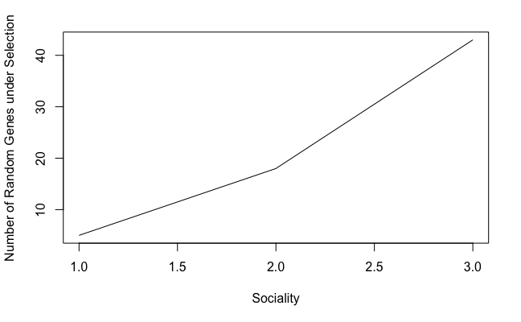

```r
plot(ran2.pos, xlab = "Sociality", ylab = "Number of Random Genes under Selection", type="l")
```

With increased sociality there is more selection occurring in the background genes. Which is to be expected after all . . .

Just for completeness, I will also run a Fisher's test on these proportions. However, with the large counts in the NoSelection categories I do not think they are appropriate.

```r
ran.test <- rbind(ran.pos, ran.tot)
rownames(ran.test) <- c("UnderSel", "NoSelection")
ran.test
```

```
            AllSol AllComplex AllOrigin
UnderSel         5         43        18
NoSelection   4934       4934      4934
```

```r
fisher.test(ran.test)
```

```
    Fisher's Exact Test for Count Data

data:  ran.test
p-value = 2.409e-08
alternative hypothesis: two.sided
```

Also significant.

# All Lineages

Let's start with everything combined, including the all runs.

```r
solitary <- c("AllSol", "Habro", "Nova", 'Mega')
social <- c("AllOrigin", "CorbSoc", "Halictid", "Xylo")
complex <- c("AllComplex", "Apis", "Meli")
```

Let's do this. Function time.

x = sociality, y = class

```r
can.count
```

```
        undersel not undersel
sol.can       18          165
soc.can       15          168
com.can       30          153
```

```r
prop.test(can.pos.3, can.tot.3)
```

[output not shown]

```r
prop.trend.test(can.pos.3, can.tot.3)
```

```
    Chi-squared Test for Trend in Proportions

data:  can.pos.3 out of can.tot.3 ,
 using scores: 1 2 3
X-squared = 11.461, df = 1, p-value = 0.0007105
```

Significantly different with a potential trend. Double check with some Fisher

```r
can.test2
```

```
     UnderSel NotUnderSel
[1,]       18         165
[2,]       15         168
[3,]       30         153
```

```r
fisher.test(can.test2)
```

```
    Fisher's Exact Test for Count Data

data:  can.test2
p-value = 0.03912
alternative hypothesis: two.sided
```

Still significant. A significant difference between socialities and number of canon genes under selection, with a trend leaning towards more social = more genes under selection.

NONCANON

```r
non.pos.3 <- as.numeric(non.count$undersel)
non.tot.3 <- as.numeric(non.count$`not undersel`)
prop.test(non.pos.3, non.tot.3)
```

```
    3-sample test for equality of proportions without continuity correction

data:  non.pos.3 out of non.tot.3
X-squared = 38.717, df = 2, p-value = 3.914e-09
alternative hypothesis: two.sided
sample estimates:
    prop 1     prop 2     prop 3
0.07389163 0.07654321 0.15803453
```

Again, significant difference between different socialities and number of noncanon genes under selection.

```r
prop.trend.test(non.pos.3, non.tot.3)
```

```
    Chi-squared Test for Trend in Proportions

data:  non.pos.3 out of non.tot.3 ,
 using scores: 1 2 3
X-squared = 29.625, df = 1, p-value = 5.242e-08
```

Highly significant trend = increased sociality, increased number of genes under selection

Double check.

```r
non.test2 <- cbind(non.pos.3, non.tot.3)
colnames(non.test2) <- c("UnderSel", "NotUnderSel")
non.test2
```

```
     UnderSel NotUnderSel
[1,]       60         812
[2,]       62         810
[3,]      119         753
```

```r
fisher.test(non.test2)
```

```
    Fisher's Exact Test for Count Data

data:  non.test2
p-value = 4.742e-07
alternative hypothesis: two.sided
```

RANDOM

```r
ran.pos.3 <- as.numeric(ran.count$undersel)
ran.tot.3 <- as.numeric(ran.count$`not undersel`)
prop.test(ran.pos.3, ran.tot.3)
```

```
    3-sample test for equality of proportions without continuity correction

data:  ran.pos.3 out of ran.tot.3
X-squared = 332.25, df = 2, p-value < 2.2e-16
alternative hypothesis: two.sided
sample estimates:
    prop 1     prop 2     prop 3
0.05925290 0.08511106 0.17280723
```

Again, significant difference between different socialities and number of random genes under selection.

```r
prop.trend.test(ran.pos.3, ran.tot.3)
```

```
    Chi-squared Test for Trend in Proportions

data:  ran.pos.3 out of ran.tot.3 ,
 using scores: 1 2 3
X-squared = 301.35, df = 1, p-value < 2.2e-16
```

Highly significant trend = increased sociality, increased number of genes under selection

Double check.

```r
ran.test2 <- cbind(ran.pos.3, ran.tot.3)
colnames(ran.test2) <- c("UnderSel", "NotUnderSel")
ran.test2
```

```
     UnderSel NotUnderSel
[1,]      276        4658
[2,]      387        4547
[3,]      727        4207
```

```r
fisher.test(non.test2)
```

```
    Fisher's Exact Test for Count Data

data:  non.test2
p-value = 4.742e-07
alternative hypothesis: two.sided
```

Check after multiple testing

```r
adjp
```

```
[1] 5.324410e-03 1.603320e-07 3.207354e-47
```

Without Melipona ??

```r
solitary <- c("Habro", "Nova", 'Mega')
social <- c("CorbSoc", "Halictid", "Xylo")
complex <- c("Apis")
```

Let's do this. Function time.

x = sociality, y = class

```r
count.craft <- function(x, y){
  pos <- data.complete$Gene[data.complete$SocOrigin %in% x
                               & data.complete$Class == paste(y)
                                & data.complete$adj_pvalue < 0.05]
  pos <- pos[!duplicated(pos)]
  no <- data.complete$Gene[data.complete$SocOrigin %in% x
                                 & data.complete$Class == paste(y)
                                 & !data.complete$Gene %in% pos]
  no <- no[!duplicated(no)]
  top <- c("undersel", "not undersel")
  bottom <- c(length(pos), length(no))
  fin <- rbind(top, bottom)
  rownames(fin) <- NULL
  colnames(fin) <- fin[1,]
  fin <- fin[-1,]
  return(fin)
}

sol.can <- count.craft(solitary, "Canon")
soc.can <- count.craft(social, "Canon")
com.can <- count.craft(complex, "Canon")

can.count <- rbind(sol.can, soc.can, com.can)
can.count <- as.data.frame(can.count)

sol.non <- count.craft(solitary, "NonCanon")
soc.non <- count.craft(social, "NonCanon")
com.non <- count.craft(complex, "NonCanon")

non.count <- rbind (sol.non, soc.non, com.non)
non.count <- as.data.frame(non.count)

sol.ran <- count.craft(solitary, "Random")
soc.ran <- count.craft(social, "Random")
com.ran <- count.craft(complex, "Random")

ran.count <- rbind(sol.ran, soc.ran, com.ran)
ran.count <- as.data.frame(ran.count)
```

```r
can.pos.3 <- as.numeric(can.count$undersel)
can.tot.3 <- as.numeric(can.count$`not undersel`)
prop.test(can.pos.3, can.tot.3)
```

[output not shown]

```r
prop.trend.test(can.pos.3, can.tot.3)
```

[output not shown]

```r
can.test2 <- cbind(can.pos.3, can.tot.3)

colnames(can.test2) <- c("UnderSel", "NotUnderSel")
can.test2
```

[output not shown]

```r
fisher.test(can.test2)
```

[output not shown]

NONCANON

```r
non.pos.3 <- as.numeric(non.count$undersel)
non.tot.3 <- as.numeric(non.count$`not undersel`)
prop.test(non.pos.3, non.tot.3)
```

[output not shown]

```r
prop.trend.test(non.pos.3, non.tot.3)
```

[output not shown]

Double check.

```r
non.test2 <- cbind(non.pos.3, non.tot.3)

colnames(non.test2) <- c("UnderSel", "NotUnderSel")
non.test2
```

[output not shown]

```r
fisher.test(non.test2)
```

[output not shown]

RANDOM

```r
ran.pos.3 <- as.numeric(ran.count$undersel)
ran.tot.3 <- as.numeric(ran.count$`not undersel`)
prop.test(ran.pos.3, ran.tot.3)
```

[output not shown]

```r
prop.trend.test(ran.pos.3, ran.tot.3)
```

[output not shown]

Double check.

```r
ran.test2 <- cbind(ran.pos.3, ran.tot.3)

colnames(ran.test2) <- c("UnderSel", "NotUnderSel")
ran.test2
```

[output not shown]

Fisher test ... even though its not appropriate in this case as we have some counts over 1000.

```r
fisher.test(non.test2)
```

[output not shown]